# Reproducible Research: Peer Assessment 2

26 September 2015

# Impact of Severe Weather Events on Public Health and Economy in the United States

## Synopsis

This document is used to analyze the impact of stroms and other severe weather events on public health and economy.The data analysis mainly address the following questions: (1) Across the United States, which types of events (as indicated in the EVTYPE variable) are most harmful with respect to population health. (2) Across the United States, which types of events have the greatest economic consequences.

## Data Processing

[output not shown]

Download data, unzip data, and read data

```r
## download files
url <- "https://d396qusza40orc.cloudfront.net/repdata%2Fdata%2FStormData.csv.bz2"
file <- "stormdata.csv.bz2"
if(!file.exists(file)){
  download.file(url, file)
}

## unzip and create folders (if those ain't exist)
unzip <- bzfile("stormData.csv.bz2", "r")
stormData <- read.csv(unzip, stringsAsFactors = FALSE)
close(unzip)

## get familiar with data
dim(stormData)
```

```
## [1] 902297     37
```

```r
names(stormData)
```

```
##  [1] "STATE__"    "BGN_DATE"   "BGN_TIME"   "TIME_ZONE"  "COUNTY"
##  [6] "COUNTYNAME" "STATE"      "EVTYPE"     "BGN_RANGE"  "BGN_AZI"
## [11] "BGN_LOCATI" "END_DATE"   "END_TIME"   "COUNTY_END" "COUNTYENDN"
## [16] "END_RANGE"  "END_AZI"    "END_LOCATI" "LENGTH"     "WIDTH"
## [21] "F"          "MAG"        "FATALITIES" "INJURIES"   "PROPDMG"
## [26] "PROPDMGEXP" "CROPDMG"    "CROPDMGEXP" "WFO"        "STATEOFFIC"
## [31] "ZONENAMES"  "LATITUDE"   "LONGITUDE"  "LATITUDE_E" "LONGITUDE_"
## [36] "REMARKS"    "REFNUM"
```

```r
head(stormData)
```

```
##   STATE__           BGN_DATE BGN_TIME TIME_ZONE COUNTY COUNTYNAME STATE
## 1       1  4/18/1950 0:00:00     0130       CST     97     MOBILE    AL
## 2       1  4/18/1950 0:00:00     0145       CST      3    BALDWIN    AL
## 3       1  2/20/1951 0:00:00     1600       CST     57    FAYETTE    AL
## 4       1   6/8/1951 0:00:00     0900       CST     89    MADISON    AL
## 5       1 11/15/1951 0:00:00     1500       CST     43    CULLMAN    AL
## 6       1 11/15/1951 0:00:00     2000       CST     77 LAUDERDALE    AL
##    EVTYPE BGN_RANGE BGN_AZI BGN_LOCATI END_DATE END_TIME COUNTY_END
## 1 TORNADO         0                                               0
## 2 TORNADO         0                                               0
## 3 TORNADO         0                                               0
## 4 TORNADO         0                                               0
## 5 TORNADO         0                                               0
## 6 TORNADO         0                                               0
##   COUNTYENDN END_RANGE END_AZI END_LOCATI LENGTH WIDTH F MAG FATALITIES
```

[output cut: 20 more lines]

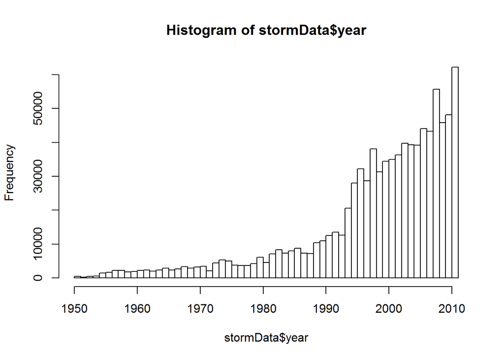

```r
if (dim(stormData)[2] == 37) {
  stormData$year <- as.numeric(format(as.Date(stormData$BGN_DATE, format = "%m/%d/%Y %H:%M:%S"), "%Y"))
}
hist(stormData$year, breaks = 50)
```

We select the data after 1980. Because “In the earlier years of the database there are generally fewer events recorded, most likely due to a lack of good records. More recent years should be considered more complete.”

```r
## subset the data from 1980 to 2010
storm <- stormData[stormData$year > 1980, ]
dim(storm)
```

```
## [1] 820785     38
```

## Impact of Severe Weather Events on Public Health

Across the United States, which types of events (as indicated in the EVTYPE variable) are most harmful with respect to population health?

```r
## sum of fatalities by event type, sort them
fatalities <- aggregate(FATALITIES~EVTYPE,storm,sum)
sort.fatalities <- fatalities[order(-fatalities$FATALITIES),]
fatalities30 <- sort.fatalities[1:30,]
```

Across the United States, which types of events (as indicated in the EVTYPE variable) are most harmful with respect to population health?

```r
## sum of injuries by event type, sort them
injuries <- aggregate(INJURIES~EVTYPE,storm,sum)
sort.injuries <- injuries[order(-injuries$INJURIES),]
injuries30<- sort.injuries[1:30,]

head(fatalities30)
```

```
##             EVTYPE FATALITIES
## 834        TORNADO       2246
## 130 EXCESSIVE HEAT       1903
## 153    FLASH FLOOD        978
## 275           HEAT        937
## 464      LIGHTNING        816
## 856      TSTM WIND        504
```

```r
head(injuries30)
```

```
##             EVTYPE INJURIES
## 834        TORNADO    36814
## 856      TSTM WIND     6957
## 170          FLOOD     6789
## 130 EXCESSIVE HEAT     6525
## 464      LIGHTNING     5230
## 275           HEAT     2100
```

## Impact of Severe Weather Events on Economy

Across the United States, which types of events have the greatest economic consequences? We focus on the property damage and crop damage that types of events cause in order to see the most costly. Sum of property damage multiplied by their respective exponent by event type, sort them

```r
unique(storm$PROPDMGEXP)
```

```
##  [1] ""  "M" "K" "B" "m" "+" "0" "5" "6" "?" "4" "2" "3" "h" "7" "H" "-"
## [18] "1" "8"
```

```r
##lets make them numeric by the multipliers in data documentation
storm$PROPEXPN[storm$PROPDMGEXP ==""] <- 1
storm$PROPEXPN[storm$PROPDMGEXP =="-"] <- 0
storm$PROPEXPN[storm$PROPDMGEXP =="?"] <- 0
storm$PROPEXPN[storm$PROPDMGEXP =="+"] <- 0
storm$PROPEXPN[storm$PROPDMGEXP =="0"] <- 1
storm$PROPEXPN[storm$PROPDMGEXP =="1"] <- 1
storm$PROPEXPN[storm$PROPDMGEXP =="2"] <- 100
storm$PROPEXPN[storm$PROPDMGEXP =="3"] <- 1000
storm$PROPEXPN[storm$PROPDMGEXP =="4"] <- 10000
storm$PROPEXPN[storm$PROPDMGEXP =="5"] <- 100000
storm$PROPEXPN[storm$PROPDMGEXP =="6"] <- 1e+06
storm$PROPEXPN[storm$PROPDMGEXP =="7"] <- 1e+07
storm$PROPEXPN[storm$PROPDMGEXP =="8"] <- 1e+08
storm$PROPEXPN[storm$PROPDMGEXP =="B"] <- 1e+09
storm$PROPEXPN[storm$PROPDMGEXP =="h"] <- 100
storm$PROPEXPN[storm$PROPDMGEXP =="H"] <- 100
storm$PROPEXPN[storm$PROPDMGEXP =="K"] <- 1000
storm$PROPEXPN[storm$PROPDMGEXP =="m"] <- 1e+06
storm$PROPEXPN[storm$PROPDMGEXP =="M"] <- 1e+06

storm$PROPDMGWITHEXP <- storm$PROPDMG * storm$PROPEXPN

pdmg <- aggregate(PROPDMGWITHEXP~EVTYPE,storm,sum)
sort.pdmg <- pdmg[order(-pdmg$PROPDMGWITHEXP),]
pdmg30 <- sort.pdmg[1:30,]
```

Sum of crop damage multiplied by their respective exponent by event type, sort them

```r
unique(storm$CROPDMGEXP) ##to see the levels
```

```
## [1] ""  "M" "K" "m" "B" "?" "0" "k" "2"
```

```r
## lets make them numeric by the multipliers in data documentation
storm$CROPEXPN[storm$CROPDMGEXP == ""] <- 1
storm$CROPEXPN[storm$CROPDMGEXP == "?"] <- 0
storm$CROPEXPN[storm$CROPDMGEXP == "0"] <- 1
storm$CROPEXPN[storm$CROPDMGEXP == "2"] <- 10
storm$CROPEXPN[storm$CROPDMGEXP == "B"] <- 1e+9
storm$CROPEXPN[storm$CROPDMGEXP == "k"] <- 1000
storm$CROPEXPN[storm$CROPDMGEXP == "K"] <- 1000
storm$CROPEXPN[storm$CROPDMGEXP == "m"] <- 1e+06
storm$CROPEXPN[storm$CROPDMGEXP == "M"] <- 1e+06

storm$CROPDMGWITHEXP <- storm$CROPDMG * storm$CROPEXPN

cdmg <- aggregate(CROPDMGWITHEXP~EVTYPE,storm,sum)
sort.cdmg <- cdmg[order(-cdmg$CROPDMGWITHEXP),]
cdmg30 <- sort.cdmg[1:30,]
```

## Results

```r
## List of the events with the largest number of fatalities.
fatalities30
```

```
##                      EVTYPE FATALITIES
## 834                 TORNADO       2246
## 130          EXCESSIVE HEAT       1903
## 153             FLASH FLOOD        978
## 275                    HEAT        937
## 464               LIGHTNING        816
## 856               TSTM WIND        504
## 170                   FLOOD        470
## 585             RIP CURRENT        368
## 359               HIGH WIND        248
## 19                AVALANCHE        224
## 972            WINTER STORM        206
## 586            RIP CURRENTS        204
## 278               HEAT WAVE        172
## 140            EXTREME COLD        160
```

[output cut: 16 more lines]

```r
## List of the events with the largest number of injuries.
injuries30
```

```
##                 EVTYPE INJURIES
## 834            TORNADO    36814
## 856          TSTM WIND     6957
## 170              FLOOD     6789
## 130     EXCESSIVE HEAT     6525
## 464          LIGHTNING     5230
## 275               HEAT     2100
## 427          ICE STORM     1975
## 153        FLASH FLOOD     1777
## 760  THUNDERSTORM WIND     1488
## 244               HAIL     1361
## 972       WINTER STORM     1321
## 411  HURRICANE/TYPHOON     1275
## 359          HIGH WIND     1137
## 310         HEAVY SNOW     1021
```

[output cut: 16 more lines]

Graphs of the fatalities and injuries by event.

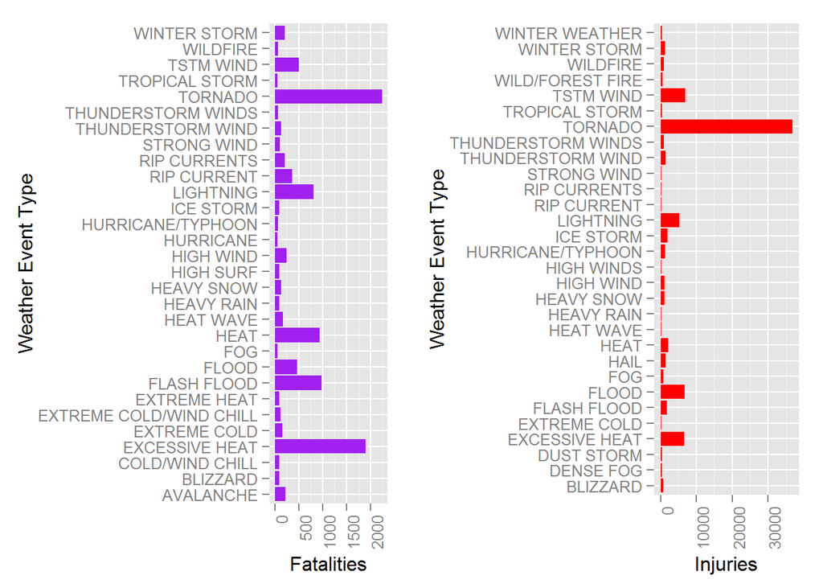

```r
library(ggplot2)
fatalitiesPlot <- ggplot(fatalities30,aes(EVTYPE,FATALITIES))+
                          geom_bar(stat="identity",fill="purple")+
                          coord_flip()+xlab("Weather Event Type")+
                          ylab("Fatalities")+
                          theme(axis.text.x = element_text(angle = 90, hjust = 1))
injuriesPlot <- ggplot(injuries30,aes(EVTYPE,INJURIES))+
                        geom_bar(stat="identity",fill="red")+
                        coord_flip()+
                        xlab("Weather Event Type")+
                        ylab("Injuries")+
                        theme(axis.text.x = element_text(angle = 90, hjust = 1))

## putting the plots in a single row
library(gridExtra)

## Loading required package: grid (some problem)
grid.arrange(fatalitiesPlot,injuriesPlot,ncol = 2)
```

```r
# List of the events with the highest economical impact(considering properties).
pdmg30
```

```
##                         EVTYPE PROPDMGWITHEXP
## 170                      FLOOD   144657709807
## 411          HURRICANE/TYPHOON    69305840000
## 670                STORM SURGE    43323536000
## 834                    TORNADO    41495981937
## 153                FLASH FLOOD    16822673979
## 244                       HAIL    15735267513
## 402                  HURRICANE    11868319010
## 848             TROPICAL STORM     7703890550
## 972               WINTER STORM     6688497251
## 359                  HIGH WIND     5270046260
## 590                RIVER FLOOD     5118945500
## 957                   WILDFIRE     4765114000
## 671           STORM SURGE/TIDE     4641188000
## 856                  TSTM WIND     4484928495
```

[output cut: 16 more lines]

```r
# List of the events with the highest economical impact(considering crops).
cdmg30
```

```
##                      EVTYPE CROPDMGWITHEXP
## 95                  DROUGHT    13972566000
## 170                   FLOOD     5661968450
## 590             RIVER FLOOD     5029459000
## 427               ICE STORM     5022113500
## 244                    HAIL     3025954473
## 402               HURRICANE     2741910000
## 411       HURRICANE/TYPHOON     2607872800
## 153             FLASH FLOOD     1421317100
## 140            EXTREME COLD     1292973000
## 212            FROST/FREEZE     1094086000
## 290              HEAVY RAIN      733399800
## 848          TROPICAL STORM      678346000
## 359               HIGH WIND      638571300
## 856               TSTM WIND      554007350
```

[output cut: 16 more lines]

Graphs of the property and crop damages by event.

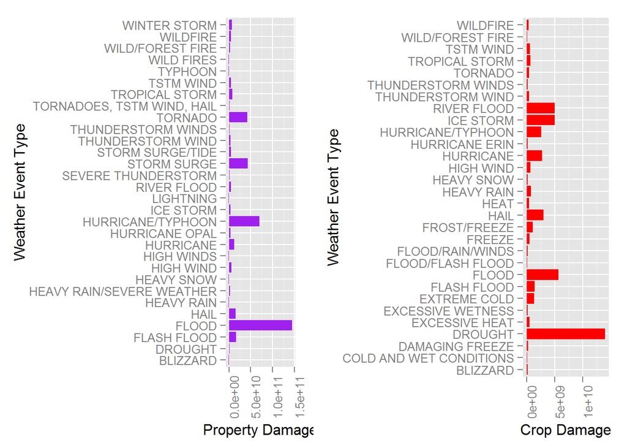

```r
propertyPlot <- ggplot(pdmg30,aes(EVTYPE,PROPDMGWITHEXP))+
                geom_bar(stat="identity",fill="purple")+
                coord_flip()+
                xlab("Weather Event Type")+
                ylab("Property Damage")+
                theme(axis.text.x = element_text(angle = 90, hjust = 1))
cropPlot<- ggplot(cdmg30,aes(EVTYPE,CROPDMGWITHEXP))+
                geom_bar(stat="identity",fill="red")+
                coord_flip()+xlab("Weather Event Type")+
                ylab("Crop Damage")+
                theme(axis.text.x = element_text(angle = 90, hjust = 1))

##putting the plots in a single row
library(gridExtra)

##putting the plots in a single row (some problem)
grid.arrange(propertyPlot,cropPlot,ncol = 2)
```

It is shown from the figure that floods are the leading cause of property damage followed by hurricanes/typhoons and storm surges. Leading cause of damage to crops are draughts and floods.